# Introduction to the thundeR package

Bartosz Czernecki, Mateusz Taszarek, Piotr Szuster

**`thundeR`** is a freeware R package and collection of functions for rapid computation and visualisation of convective parameters commonly used in the operational forecasting of severe convective storms. Core algorithm is based on C++ code implemented into R language via RCPP. This solution allows to compute over 100 thermodynamic and kinematic parameters in less than 0.02s per profile and process large datasets such as reanalyses or operational NWP models in a reasonable amount of time. Package has been developed since 2017 by research meteorologists specializing in severe convective storms and is constantly updated with new features.

## Online browser:

Online rawinsonde browser of `thundeR` package is available at www.rawinsonde.com

## Main functions:

- **`sounding_compute()`** - A core function for calculating convective parameters commonly used in the operational prediction of severe convective storms. Returns a vector of parameters.
- **`sounding_plot()`** - Function to plot a composite of Skew-T, hodograph and selected convective parameters on a single layout
- **`sounding_save()`**`- Auxiliary function to`sounding_plot` that plots a composite of Skew-T, hodograph and selected convective parameters on a single layout and exports graphical file.
- **`get_sounding()`** - Download rawinsonde measurement from sounding database of the University of Wyoming in a form convenient to use with `thundeR` package.

## Examples

Examples show aplication of selected `thundeR` package functions

### Example 1

Draw Skew-T, hodograph and convective parameters on a single layout and export to png file:

```r
library(thunder)
data("sounding_vienna") # load example dataset (Vienna rawinsonde profile for 23 Aug 2011 12UTC):
pressure = sounding_vienna$pressure # vector of pressure [hPa]
altitude = sounding_vienna$altitude # vector of altitude [meters]
temp = sounding_vienna$temp  # vector of temperature [degree Celsius]
dpt = sounding_vienna$dpt # vector of dew point temperature [degree Celsius]
wd = sounding_vienna$wd # vector of wind direction [azimuth in degrees]
ws = sounding_vienna$ws # vector of wind speed [knots]
sounding_save(filename = "Vienna.png", title = "Vienna - 23 August 2011 1200 UTC", pressure, altitude, temp, dpt, wd, ws)
```

```
#> Your display device is 10 x 6 in.
#> It is recommended to use at least 10 x 7.5 in. plotting window
#> or consider saving the layout into file
```

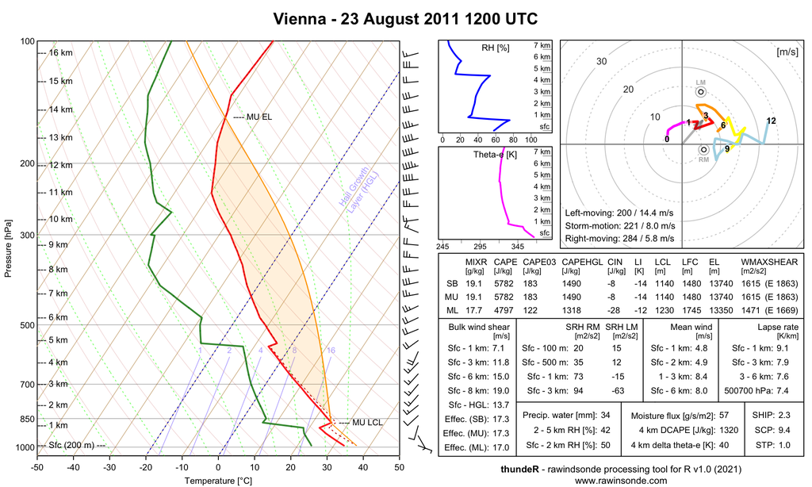

### Example 2

Download North Platte rawinsonde profile for 03 Jul 1999 00UTC and export to png file:

```r
profile = get_sounding(wmo_id = 72562, yy = 1999, mm = 7, dd = 3, hh = 0)
```

```
#> [1] "http://weather.uwyo.edu/cgi-bin/sounding?region=europe&TYPE=TEXT%3ALIST&YEAR=1999&MONTH=07&FROM=0300&TO=0300&STNM=72562"
#> /var/folders/lw/3fnnk87n4q1dkl35s2_p24h80000gn/T//RtmpmShbLB/file4bc9506766ac
```

```r
head(profile) # show first few rows of downloaded dataset
```

```
#>   pressure altitude temp dpt  wd ws
#> 3      906      849   32  26 110 14
#> 4      899      914   31  25 120 14
#> 5      869     1219   28  22 145 13
#> 6      850     1414   26  21 155 15
#> 7      811     1829   22  19 175 17
#> 8      802     1924   21  19 183 17
```

```r
sounding_save(filename = "NorthPlatte.png", title = "North Platte - 03 July 1999 0000 UTC", profile$pressure, profile$altitude, profile$temp, profile$dpt, profile$wd, profile$ws)
```

```
#> Your display device is 10 x 6 in.
#> It is recommended to use at least 10 x 7.5 in. plotting window
#> or consider saving the layout into file
```

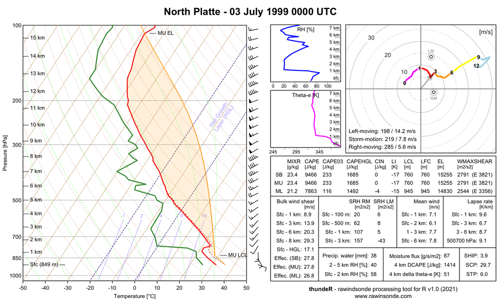